[figure not shown]

[figure not shown]

Report Writing for Data Science in R

Roger D. Peng

This book is for sale at http://leanpub.com/reportwriting

This version was published on 2019-04-17

* * * * *

This is a Leanpub book. Leanpub empowers authors and publishers with the

Lean Publishing process. Lean Publishing is the act of publishing an in-

progress ebook using lightweight tools and many iterations to get reader

feedback, pivot until you have the right book and build traction once you

do.

* * * * *

© 2015 - 2019 Roger D. Peng

[figure not shown]

Table of Contents

Stay in Touch!

1. Getting Started with R

2. What is Reproducible Reporting?

3. The Data Science Pipeline

4. Literate Statistical Programming

5. Organizing a Data Analysis

6. Structure of a Data Analysis: Part 1

7. Structure of a Data Analysis: Part 2

8. Markdown

9. Using knitr for Reproducible Reports

10. Communicating Results Over E-mail

11. Reproducibility Check List

12. Evidence-based Data Analysis

13. Public Reproducibility Resources

About the Author

[figure not shown]

Stay in Touch!

Thanks for purchasing this book. If you are interested in hearing more from

me about things that I’m working on (books, data science courses, podcast,

etc.), you can do two things.

First, I encourage you to join my mailing list of Leanpub Readers. On this

list I send out updates of my own activities as well as occasional comments

on data science current events. I’ll also let you know what my co-

conspirators Jeff Leek and Brian Caffo are up to because sometimes they do

really cool stuff.

Second, I have a regular podcast called Not So Standard Deviations that I

co-host with Dr. Hilary Parker, a Senior Data Analyst at Etsy. On this

podcast, Hilary and I talk about the craft of data science and discuss

common issues and problems in analyzing data. We’ll also compare how

data science is approached in both academia and industry contexts and

discuss the latest industry trends.

You can listen to recent episodes on our SoundCloud page or you can

subscribe to it in iTunes or your favorite podcasting app.

Thanks again for purchasing this book and please do stay in touch!

[figure not shown]

1. Getting Started with R

Installation

The first thing you need to do to get started with R is to install it on your

computer. R works on pretty much every platform available, including the

widely available Windows, Mac OS X, and Linux systems. If you want to

watch a step-by-step tutorial on how to install R for Mac or Windows, you

can watch these videos:

Installing R on Windows

Installing R on the Mac

There is also an integrated development environment available for R that is

built by RStudio. I really like this IDE—it has a nice editor with syntax

highlighting, there is an R object viewer, and there are a number of other

nice features that are integrated. You can see how to install RStudio here

Installing RStudio

The RStudio IDE is available from RStudio’s web site.

Getting started with the R interface

After you install R you will need to launch it and start writing R code.

Before we get to exactly how to write R code, it’s useful to get a sense of

how the system is organized. In these two videos I talk about where to write

code and how set your working directory, which let’s R know where to find

all of your files.

Writing code and setting your working directory on the Mac

Writing code and setting your working directory on Windows

[figure not shown]

2. What is Reproducible Reporting?

Watch a video of this chapter.

This chapter will be about reproducible reporting, and I want to take the

opportunity to cover some basic concepts and ideas that are related to

reproducible reporting, just in case you haven’t heard about it or don’t

know what it is.

Before we get to reproducibility, we need to cover a little background with

respect to how science works (even if you’re not a scientist, this is

important). The basic idea is that in science, replication is the most

important element of verifying and validating findings. So if you claim that

X causes Y, or that Vitamin C improves disease, or that something causes a

problem, what happens is that other scientists that are independent of you

will try to investigate that same question and see if they come up with a

similar result. If lots of different people come up with the same result and

replicate the original finding, then we tend to think that the original finding

was probably true and that this is a real relationship or real finding.

The ultimate standard in strengthening scientific evidence is replication.

The goal is to have independent people to do independent things with

different data, different methods, and different laboratories and see if you

get the same result. There’s a sense that if a relationship in nature is truly

there, then it should be robust to having different people discover it in

different ways. Replication is particularly important in areas where findings

can have big policy impacts or can influence regulatory types of decisions.

What’s Wrong with Replication?

What’s wrong with replication? There’s really nothing wrong with it. This

is what science has been doing for a long time, through hundreds of years.

And there’s nothing wrong with it today. But the problem is that it’s

becoming more and more challenging to do replication or to replicate other

studies. Part of the reason is because studies are getting bigger and bigger.

In order to do big studies you need a lot of money and so, well, there’s a lot

of money involved! If you want to do ten versions of the same study, you

need ten times as much money and there’s not as much money around as

there used to be. Sometimes it’s difficult to replicate a study because if the

original study took 20 years to do, it’s difficult to wait around another 20

years for replication. Some studies are just plain unique, such as studying

the impact of a massive earthquake in a very specific location and time. If

you’re looking at a unique situation in time or a unique population, you

can’t readily replicate that situation.

There are a lot of good reasons why you can’t replicate a study. If you can’t

replicate a study, is the alternative just to do nothing, just let that study

stand by itself? The idea behind a reproducible reporting is to create a kind

of minimum standard or a middle ground where we won’t be replicating a

study, but maybe we can do something in between. The basic problem is

that you have the gold standard, which is replication, and then you have the

worst standard which is doing nothing. What can we do that’s in between

the gold standard and diong nothing? That is where reproducibility comes

in. That’s how we can kind of bridge the gap between replication and

nothing.

In non-research settings, often full replication isn’t even the point. Often the

goal is to preserve something to the point where anybody in an organization

can repeat what you did (for example, after you leave the organization). In

this case, reproducibility is key to maintaining the history of a project and

making sure that every step along the way is clear.

Reproducibility to the Rescue

Why do we need this kind of middle ground? I haven’t clearly defined

reproducibility yet, but the basic idea is that you need to make the data

available for the original study and the computational methods available

so that other people can look at your data and run the kind of analysis that

you’ve run, and come to the same findings that you found.

What reproducible reporting is about is a validation of the data analysis.

Because you’re not collecting independent data using independent methods,

it’s a little bit more difficult to validate the scientific question itself. But if

you can take someone’s data and reproduce their findings, then you can, in

some sense, validate the data analysis. This involves having the data and the

code because more likely than not, the analysis will have been done on the

computer using some sort of programming language, like R. So you can

take their code and their data and reproduce the findings that they come up

with. Then you can at least have confidence that the analysis was done

appropriately and that the correct methods were used.

Recently, there’s been a lot of discussion of reproducibility in the media and

in the scientific literature. The journal Science had a special issue on

reproducibility and data replication. Other journals of updated policies on

publication to encourage reproducibility. In 2012, a feature on the TV show

60 minutes looked at a major incident at Duke University where many

results involving a promising cancer test were found to be not reproducible.

This led to a number of studies and clinical trials having to be stopped,

followed by an investigation which is still ongoing.

Finally, the Institute of Medicine, in response to a lot of recent events

involving reproducibility of scientific studies, issued a report saying that

best practices should be done to promote and encourage reproducibility,

particularly in what’s called ‘omics based research, such as genomics,

proteomics, other similar areas involving high-throughput biological

measurements. This was a very important report. Of the many

recommendations that the IOM made, the key ones were that

Data and metadata need to be made available;

Computer code should be fully specified, so that people can examine it

to see what was done;

All the steps of the computational analysis, including any

preprocessing of data, should be fully described so that people can

study it and reproduce it.

From “X” to “Computational X”

What is driving this need for a “reproducibility middle ground” between

replication and doing nothing? For starters, there are a lot of new

technologies on the scene and in many different fields of study including,

biology, chemistry and environmental science. These technologies allow us

to collect data at a much higher throughput so we end up with these very

complex and very high dimensional data sets. These datasets can be

collected almost instantaneously compared to even just ten years ago—the

technology has allowed us to create huge data sets at essentially the touch

of a button. Furthermore, we the computing power to take existing (already

huge) databases and merge them into even bigger and bigger databases.

Finally, the massive increase in computing power has allowed us to

implement more sophisticated and complex analysis routines.

The analyses themselves, the models that we fit and the algorithms that we

run, are much much more complicated than they used to be. Having a basic

understanding of these algorithms is difficult, even for a sophisticated

person, and it’s almost impossible to describe these algorithms with words

alone. Understanding what someone did in a data analysis now requires

looking at code and scrutinizing the computer programs that people used.

The bottom line with all these different trends is that for every field “X”,

there is now “Computational X”. There’s computational biology,

computational astronomy—whatever it is you want, there is a

computational version of it.

Air Pollution and Health: A Perfect Storm

One example of an area were reproducibility is important comes from

research that I’ve conducted in the area of air pollution and health. Air

pollution and health is a big field and it involves a confluence of features

that emphasize the need for reproducibility.

The first feature is that we’re estimating very small, but very important,

public health effects in the presence of a numerous much stronger signals.

You can think about air pollution as something that’s perhaps harmful, but

even if it were harmful there are likely many other things that are going to

be more harmful that you have to worry about. Pollution is going to be at

Second, the results of a lot of air pollution research inform substantial

policy decisions. Many federal air pollution regulations in the United States

are based on scientific research in this area and these regulations can affect

a lot of stakeholders in government and industry.

Finally, we use a lot of complex statistical methods to do these studies and

these statistical methods are subsequently subjected to intense scrutiny. The

combination of an inherently weak signal, substantial policy impacts, and

complex statistical methods almost require that the research that we do be

reproducible.

Summary

Replication, whereby scientific questions are examined and verified

independently by different scientists, is the gold standard for scientific

validity.

Replication can be difficult and often there are no resources to

independently replicate a study.

Reproducibility, whereby data and code are re-analyzed by

independent scientists to obtain the same results of the original

investigator, is a reasonable minimum standard when replication is not

possible.

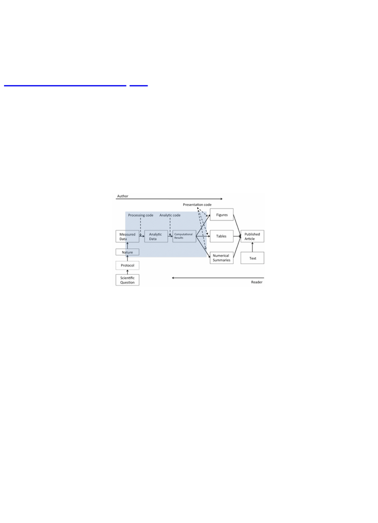

3. The Data Science Pipeline

Watch a video of this chapter.

The basic issue is when you read a description of a data analysis, such as in

an article or a technical report, for the most part, what you get is the report

and nothing else. Of course, everyone knows that behind the scenes there’s

a lot that went into this report and that’s what I call the data science

pipeline.

The Data Science Pipeline

In this pipeline, there are two “actors”: the author of the report/article and

the reader. On the left side, the author is going from left to right along this

pipeline. The reader is going from right to left. If you’re the reader you read

the article and you want to know more about what happened: Where is the

data? What was used here? The basic idea behind reproducibility is to focus

on the elements in the blue blox: the analytic data and the computational

results. With reproducibility the goal is to allow the author of a report and

the reader of that report to “meet in the middle”.

Elements of Reproducibility

What do we need for reproducibility? There’s a variety of ways to talk

about this, but one basic definition that we’ve come up with is that there are

four things that are required to make results reproducible:

1. Analytic data. The data that were used for the analysis that was

presented should be available for others to access. This is different

from the raw data because very often in a data analysis the raw data

are not all used for the analysis, but rather some subset is used. It may

be interesting to see the raw data but impractical to actually have it.

Analytic data is key to examining the data analysis.

2. Analytic code. The analytic code is the code that was applied to the

analytic data to produce the key results. This may be preprocessing

code, regression modeling code, or really any other code used to

produce the results from the analytic data.

3. Documentation. Documentation of that code and the data is very

important.

4. Distribution. Finally, there needs to be some standard means of

distribution, so all this data in the code is easily accessible.

Authors and Readers

It is important to realize that there are multiple players when you talk about

reproducibility–there are different types of parties that have different types

of interests. There are authors who produce research and they want to make

their research reproducible. There are also readers of research and they

want to reproduce that work. Everyone needs tools to make their lives

easier.

One current challenge is that authors of research have to undergo

considerable effort to make their results available to a wide audience.

Publishing data and code today is not necessarily a trivial task. Although

there are a number of resources available now, that were not available even

five years ago, it’s still a bit of a challenge to get things out on the web (or

at least distributed widely). Resources like GitHub and RPubs and various

data repositories have made a big difference, but there is still a ways to go

with respect to building up the public reproducibility infrastructure.

Furthermore, even when data and code are available, readers often have to

download the data, download the code, and then they have to piece

everything together, usually by hand. It’s not always an easy task to put the

data and code together. Also, readers may not have the same computational

resources that the original authors did. If the original authors used an

enormous computing cluster, for example, to do their analysis, the readers

may not have that same enormous computing cluster at their disposal. It

may be difficult for readers to reproduce the same results.

Generally the toolbox for doing reproducible research is small, although it’s

definitely growing. In practice, authors often just throw things up on the

web. There are journals and supplementary materials, but they are famously

disorganized. There are only a few central databases that authors can take

advantage of to post their data and make it available. So if you’re working

in a field that has a central database that everyone uses, that’s great. If

you’re not, then you have to assemble your own resources.

Summary

The process of conducting and disseminating research can be depicted

as a “data science pipeline”

Readers and consumers of data science research are typically not privy

to the details of the data science pipeline

One view of reproducibility is that it gives research consumers partial

access to the raw pipeline elements.

[figure not shown]

4. Literate Statistical Programming

Watch a video of this chapter.

One basic idea to make writing reproducible reports easier is what’s known

as literate statistical programing (or sometimes called literate statistical

practice). This comes from the idea of literate programming in the area of

writing computer programs.

The idea is to think of a report or a publication as a stream of text and code.

The text is readable by people and the code is readable by computers. The

analysis is described in a series of text and code chunks. Each kind of code

chunk will do something like load some data or compute some results. Each

text chunk will relay something in a human readable language. There might

also be presentation code that formats tables and figures and there’s article

text that explains what’s going on around all this code. This stream of text

and code is a literate statistical program or a literate statistical analysis.

Weaving and Tangling

Literate programs by themselves are a bit difficult to work with, but they

can be processed in two important ways. Literate programs can be weaved

to produce human readable documents like PDFs or HTML web pages, and

they can tangled to produce machine-readable “documents”, or in other

words, machine readable code. The basic idea behind literate programming

in order to generate the different kinds of output you might need, you only

need a single source document—you can weave and tangle to get the rist. In

order to use a system like this you need a documentational language, that’s

human readable, and you need a programming language that’s machine

readable (or can be compiled/interpreted into something that’s machine

readable).

Sweave

One of the original literate programming systems in R that was designed to

do this was called Sweave. Sweave uses a documentation program called

LaTeX and a programming language, which obviously is R. It was

originally developed by Fritz Leisch, who is a core member of R, and the

code base is still maintained by R Core. The Sweave system comes with a

any installation of R.

There are many limitations to the original Sweave system. One of the

limitations is that it is focused primarily on LaTeX, which is not a

documentation language that many people are familiar with. Therefore, it

can be difficult to learn this type of markup language if you’re not already

in a field that uses it regularly. Sweave also lacks a lot of features that

people find useful like caching, and multiple plots per page and mixing

programming languages.

knitr

One of the alternative that has come up in recent times is something called

knitr. The knitr package for R takes a lot of these ideas of literate

programming and updates and improves upon them. knitr still uses R as its

programming language, but it allows you to mix other programming

languages in. You can also use a variety of documentation languages now,

such as LaTeX, markdown and HTML. knitr was developed by Yihui Xie

while he was a graduate student at Iowa State and it has become a very

popular package for writing literate statistical programs.

Summary

Literate statistical programming tools can make it easier to write up

reproducible documents containing data analyses.

Sweave was one of the first literate statistical programming tools,

which weaved together a statistical language (R) with a markup

language (LaTeX).

knitr is a package that builds on the work of Sweave and provides

much more powerful functionality, including the ability to write in

Markdown and create a variety of output formats.

5. Organizing a Data Analysis

In this chapter, I’m going to give a couple of basic notes on how to organize

a data analysis. Of course, there’s no universal way to do this that would

apply to every single data analysis performed by anybody in the world, but

I think there’s some useful tips that can be used to help you put things

together in logical places and ultimately ensure that your data analysis is

reproducible either by yourself or by someone else.

Files Files Files…

The kind of key data analysis files that you will retain over the course of a

major project are going to be raw data and processed data and you’re

probably going to want to save a lot of this in various places. You’ll

generate some figures or tables, for example, and they’re going to be

exploratory figures that you put together to look at the data to produce this

rough cut of what the data analysis might look like. These exploratory

figures are not going to be very polished. They’ll be just good enough to get

you a sense of what the data look like. Then there might be some final

figures. These final figures are going to be useful for you to put in reports.

These are the figures you’re going to show to other people, they’re going to

be well annotated and nicely organized and put together.

Of course, there’s going to be some code. There might be some R code in

the form of both raw and unused scripts. These are kind of things that you

code up to see what’s going on, perhaps in the process of making

exploratory figures. Thereâ€™s going to be R code that you eventually

don’t use in the end. So, you’ll have some scripts lying around. There will

be some final scripts that you use in the final analysis. And these will,

hopefully, be easier to read, commented and formatted better. And then you

might be running some R markdown files that annotate a data analysis

using a literate statistical programming style.

And finally there’s going to be some text that you write, either in the form

of README files that explain what’s going on in your project, a more

formal report that you have to write, or even a paper that you plan on

publishing. All this text is going to integrate everything you’ve done in this

data analysis, with the data, the figures, the tables, and the R code.

Raw and Processed Data

The raw data will come in any number of different forms. They might

come, for example, as just records or as formatted text. You’re going to do

something to this raw data to make it usable for an analysis type of

program. For example, you might do some text processing. You might try to

parse the data and if it’s formatted in a special format, you can generate

something that can be later used for modeling or other types of analysis.

You want to store this raw data in your analysis folder if you’re working on

a project. If the data were accessed from the web you want to include things

like the URL, where you got the data, what the data set is, a brief

description of what it’s for, the date that you accessed the URL on, the

website, etc. You may want this in a README file so when you look at it

later, or if someone else looks at it, they know where this data came from

and what it’s for.

Another thing that I like to do, if you’re using git or an equivalent version

control system to track things that are going on in your project, is to add

your data set, your raw data, if possible. If it’s too big then it’s not really

feasible. But you can add your raw data to the repository and, in the log

message, when you add it you can talk about what the website was where

you got it, what the URL was, et cetera. That’s a convenient place to put

this kind of information.

Processed data is usually cleaner than the raw data. It can come in a variety

of forms. One common format is a table. Your processed data should be

named so that you can easily see what script generated what data. The

processing script is very important because it shows you how the raw data

were mapped to the processed data. In any README file or any sort of

documentation, it’s important to document what code files were used to

transform the raw data into the processed data. Finally, the processed data

should be tidy so that you can use them in subsequent modeling or analysis

types of functions.

Figures

Exploratory figures are usually very simple figures. These are figures that

you make in the course of your analysis as you’re getting a look at the data.

Typically, your data will be high dimensional because you’ll be collecting

lots of variables on lots of subjects or observations. You’re going to be able

to look at pieces of the data at a time. Exploratory figures serve the role

of giving you a quick look at various aspects of your data. They’re not

all necessarily going to be part of your final report or final paper. You’ll

tend to make a bunch of these along the way. They don’t need to be pretty,

but they need to be usable enough so that you understand what’s going on

in the figure and how to reproduce it. Final figures will generally be much

more polished, better organized and much more readable.

The final figures usually make a very small subset of the set of exploratory

figures that you might generate. For example, the typical paper in a journal

might have four or maybe five figures in it because these figures take up a

lot of space. You typically don’t want to inundate people with a lot of

figures because then the ultimate message of what you’re trying to

communicate tends to get lost in a pile of figures. It’s important to have

these final figures labeled well and annotated so people understand what’s

going on with the data.

Scripts

As you’re doing a data analysis you’ll probably burn through a lot of

different R scripts and code files for various purposes. There will be a lot of

dead ends that you’ll go down, and there will be many R scripts that don’t

play into the final analysis. These R scripts are going to be less commented

and contain just code that puts some stuff together. You may have multiple

versions of these code files, which, typically, will include analyses that are

later discarded.

Final scripts will be much more clearly commented. You’ll likely have

bigger comment blocks for whole sections of code. There will be a lot of

small comments explaining what’s going on. Any processing details of any

code that is used to process the raw data would be important to include.

Basically these final scripts are for any analysis that would appear in a final

write up of paper.

Itâ€™s important when people see a final a product like a paper or a report

that they understand what scripts went into this report and what processing

and analysis scripts might have gone into this. Then they can see the chain

of events that occurred. It’s important, of course, to keep a lot of the other

stuff that was not used in the final report just in case someone may want to

look at some of the dead ends that he went down. But that can be placed in

a separate part of the project directory.

R Markdown Files

R Markdown files are also very useful (see later chapter for details). They

may not be exactly required, but they can be very useful to summarize parts

of an analysis or an entire analysis. R Markdown files can be used to

generate reproducible reports. You can embed code and text into the same

document and then you process the document into something readable like

a webpage or a PDF file. These are very easy to create in RStudio and they

can be useful as an intermediate step either between just kind of code

scripts, code files, data and a polished final report.

If you don’t use R markdown files you may want to have README files

that explain what’s going on so you or another person can get a sense of the

organization of the project. They could contain step by step instructions for

how the analysis is conducted, what code files are called first, what are used

to process the data, what are used to fit models, and what are used to kind

of generate figures and things like that.

Final Report

Finally, in the end you’ll probably produce a document or report, maybe a

paper or summary of all of the analysis that you did. The point of this is to

tell the final story of what you generated here. Typically you’ll have a title,

an introduction that motivates your problem, the methods that you used to

refine, the results and any measures of uncertainty, and then any

conclusions that you might draw from the data analysis that you did,

including any pitfalls or potential problems. The important thing is that you

need to tell a coherent story, to take all the analysis that you did and kind of

winnow it down into a final product that has a coherent story to it.

Don’t dump

You definitely should not include every analysis that you performed

through the whole process, so there may be many analysis that you did but

you want to narrow it down to the important parts. That does not mean you

need to delete everything that you’ve ever did but the summary report

should not include everything. And you should always include some

references for the statistical methods that you use. That way people know

what you used, what software you used, and what implementation was

used. This is very important for again for reproducibility by others.

Summary

That’s a quick overview of how to organize your data analysis, just some

basic tips because every data analysis will have its specific details. There is

no best way to organize a data analysis, but there are some useful guidelines

that can help you maintain the reproducibility of your work. Most analyses

move in the direction of “raw” to “final” or “processed”. There are raw data

and processed data, exploratory plots and final plots, raw scripts and final

scripts. R Markdown files can be useful for bringing all these “final”

elements together.

6. Structure of a Data Analysis: Part 1

This chapter will talk about the basic process by which data analysis will

unfold. Of course, not every data analysis is the same and not every data

analysis will require the same components. But I think this will serve as a

useful template for understanding what the pieces of a data analysis are and

how they typically flow together. If one were to write down the steps in a

data analysis, you might come up with something along these lines of the

following list

Defining the question

Defining the ideal dataset

Determining what data you can access

Obtaining the data

Cleaning the data

Exploratory data analysis

Statistical prediction/modeling

Interpretation of results

Challenging of results

Synthesis and write up

Creating reproducible code

There may be little things that you might want to add or delete, but most

data analyses have some subset of these steps.

What we’re going to talk about in this chapter, Part 1, is defining the

question that you’re interested in, the ideal data set, determining what data

you actually can access, and obtaining and cleaning the data. In the next

chapter we’ll talk about the remaining topics listed here.

I think the key challenge in pretty much any data analysis was well

characterized by Dan Meyer, a former high school mathematics educator. In

his TED Talk he said, “Ask yourselves what problem you have ever solved,

that was worth solving, where you knew all the given information in

advance, where you didn’t have a surplus of information and have to filter it

out, or you had insufficient information and had to go find some.” That’s a

key element of data analysis; typically, you don’t have all the facts or you

have too much information and you have to go through it. Much of the

process of data analysis is sorting through all of this stuff. So, the first part

of data analysis that you want to start with is defining a question.

The Question

Not every data analysis starts with a very specific or coherent question. But

the more effort you can put into coming up with a reasonable question, the

less effort you’ll spend having to filter through a lot of stuff. Because

defining a question is the most powerful dimension reduction tool you

can ever employ. If you’re interested in a specific variable, like height or

weight, then you can remove a lot of other variables that don’t really pertain

to those criteria at all. But if you’re interested in a different type of variable

then you can remove another subset. The idea is, if you can narrow down

your question as specifically as possible, you’ll reduce the kind of noise that

you’ll have to deal with when you’re going through a potentially very large

data set. Now, sometimes you only want to look at a data set and see what is

inside of the data set. Then you’ll have to explore all kinds of things in a

large data set. But if you can narrow down your interest to a specific type of

question, it is extremely useful for simplifying your problem.

I encourage you to think about what type of question you’re interested in

answering before you go delving into all the details of your data set. The

science, generally speaking, will determine what type of question you’re

interested in asking. That will lead you to the data. Which may lead you to

applied statistics, which you use to analyze the data. If you get really

ambitious you might want to think of some theoretical statistics that will

generalize the methods that you apply to different types of data. Now, of

course, there are relatively few people who can do that, and so I it would

not be expected of everyone.

A key problem is if you randomly apply statistical methods to datasets to

find an interesting answer you will almost certainly find something

interesting, but it may not be reproducible and it may not be really

meaningful. A proper data analysis has a scientific context, and at least

some general question that we’re trying to investigate which will narrow

down the kind of dimensionality of the problem. Then we’ll apply the

appropriate statistical methods to the appropriate data.

Let’s start with the very basic example of a question. A general question

might be: can I automatically detect emails that are spam and those that are

not? Of course, this is an important question if you use email and you want

to know which emails you should read, that are important, and which

emails are just spam. If you want to turn that into a data analysis problem

there are many ways to answer the question. For example, you could hire

someone to go through your email and figure out what’s spam and what’s

not. But that’s not really sustainable, and it’s not particularly efficient. So, if

you want to turn this into a data analysis question, you have to make the

question a little bit more concrete and translate it using terms that are

specific to data analysis tools.

A more concrete version of this question might be: can I use quantitative

characteristics of the emails themselves to classify them as spam? Now we

can start looking at emails and try to identify these quantitative

characteristics that I want to develop so that I can classify them as spam.

You’ve got a question, “How do I separate out my email so that I know

what’s spam and what’s not?” Ultimately, you can get rid of all the spam

and just read the real email.

The Ideal Dataset

The first thing you might want to think about is what is the ideal data set for

this problem? If I had all the resources in the world, what would I go out to

look for? There are different types of data sets that you could potentially

collect depending on the goal and the type of question you’re asking.

If you’re interested in a descriptive problem, you might think of a whole

population. You don’t need to sample anything. You might want to get the

entire census or population that you’re looking for. So all the emails in the

universe, for example. If you just want to explore your question, you might

take a random sample with a bunch of variables measured.

If you want to make inference about a problem then you have to be very

careful about the sampling mechanism and the definition of the population

that you are sampling from. Typically, when you make an inferential

statement, you use your smaller sample to make a conclusion about a larger

population. Therefore, the sampling mechanism is very important. If you

want to make a prediction, you need something like a training set and a test

data set from a population that you’re interested in so that you can build a

model and a classifier.

If you want to make a causal statement, such as “if I modify this

component, then something else happens,” you’re going to need

experimental data. One type of experimental data is from something like a

randomized trial or a randomized study. If you want to make mechanistic

types of statements, you need data about all the different components of the

system that you’re trying to describe.

For our problem with spam, perhaps you use Gmail. You know that all the

emails in the Gmail system are going to be stored on Google’s data centers.

Why don’t we just get all the data (emails) in Google’s data centers? That

would be a whole population of emails. Then we can just build our

classifier based on all this data and we wouldn’t have to worry about

sampling because we’d have all the data. That would be an example of an

ideal data set.

Of course, in the real world, you have to think about what data you can

actually access, right? Maybe someone at Google can actually access all the

emails that go through Gmail, but even in that extreme case, it may be

difficult. Furthermore, most people are not going to be able to access that.

So, sometimes you have to go for something that is not quite the ideal data

set. You might be able to find free data on the web. You might need to buy

some data from a provider, being sure to respect the terms of use for the

data. Any agreement or contract that you agree to about the data has to be

adhered to. If the data simply does not exist out there, you may need to

generate the data yourself in some way.

The Real Dataset

Getting all the data from Google will probably not be possible. I’m

guessing their data centers have some very high security, so we’re going to

have to go with something else. One possible solution comes from the UCI

machine learning repository, which is the spam data set. This is a collection

of spam in a data set created by people at Hewlett Packard who collected

several thousand spam and regular messages, then classified them

appropriately. You can use this database to explore your problem of how to

classify emails into spam. When you obtain the data, the first goal is to try

to obtain the raw data. For example, from the UCI machine learning

repository.

You have to be careful to reference the source, so wherever you get the data

from, you should always reference and keep track of where it came from. If

you need to get data from a person or an investigator that you’re not

familiar with, often a very polite email will go a long way. They may be

willing to share that data with you. If you get data from an Internet source,

you should always make sure at the very minimum to record the URL,

which is the web site indicator of where you got the data, and the time and

date that you accessed it so people have a reference of when that data was

available. In the future, the website might go down or the URL may change

or may not be available, but at least at the time you got that data you

documented how you got it.

Cleaning the Data

The data set that we’re going to talk about in this example, since we don’t

have access to Google’s data centers, is the spam data set which you can get

from the kernlab package in R. If you install the kernlab package, you can

load the data set right away. The first thing that you typically need to do

with any data set is to clean it a little bit. Raw data typically needs to be

processed in some way to get it into a form where you can model it or feed

it into a modeling program.

If the data is already pre-processed, it’s important that you understand how

it was done. Try to get some documentation about what the pre-processing

was and how it was done. You have to understand kind of where the data

come from, so for example if it came from a survey, you need to know how

the sampling was done. Was it a convenience sample, or did the data come

from an observational study, or perhaps from experiments? The source of

the data is very important. You may need to reformat the data in a certain

way to get it to work in a certain type of analysis. If the data set is

extremely large you may want to sub-sample the data set to make it more

manageable.

It is very important that anything you do to clean the data is recorded. Write

down these steps in scripts or whatever is most convenient because you or

someone else is going to have to reproduce these steps if they want to

reproduce your findings. If you don’t document all these pre-processing

steps, then no one will ever be able to do it again.

Once you have cleaned the data and you have gotten a basic look at it, it is

important to determine if the data are good enough to solve your problems.

In some cases, you may determine that the data are not good enough. For

example, you may not have enough data, you may not have enough

variables or enough characteristics, or the sampling of the data may be

inappropriate for your question. There may be all kinds of problems that

occur to you as you clean the data.

If you determine the data are not good enough for your question, then

you’ve got to quit, try again, change the data, or try a different question. It

is important to not simply push on with the data you have, just because

that’s all that you’ve got, because that can lead to inappropriate inferences

or conclusions.

Here is our cleaned data set from the kernlab package that we’re going to

use for this example. It’s already been cleaned for us, in the kernlab

package, and I’m just showing you the first five variables here. There are

many other variables in the data set but you can see that there are 4601

observations of the five variables. You can learn more about the dataset

here, where it shows you where the data set came from and how it’s

processed.

library(kernlab)

data(spam)

str(spam[, 1:5])

'data.frame': 4601 obs. of 5 variables:

$ make : num 0 0.21 0.06 0 0 0 0 0 0.15 0.06 ...

$ address: num 0.64 0.28 0 0 0 0 0 0 0 0.12 ...

$ all : num 0.64 0.5 0.71 0 0 0 0 0 0.46 0.77 ...

$ num3d : num 0 0 0 0 0 0 0 0 0 0 ...

$ our : num 0.32 0.14 1.23 0.63 0.63 1.85 1.92 1.88 \

0.61 0.19 ...

Note if the kernlab package isn’t installed, you can install it from CRAN

using the install.packages() function.

7. Structure of a Data Analysis: Part 2

Jumping off from the previous chapter, we can define some further steps in

a data analysis to be

Exploratory data analysis

Statistical prediction/modeling

Interpretation of results

Challenging of results

Synthesis and write up

Creating reproducible code

Understanding each of these steps and documenting them carefully through

scripts and other tools is essential for reproducibility.

In this chapter, we’re going to continue the data analysis example that we

started in part one. If you recall, we laid down a list of steps that generally

one might take when doing a data analysis. And previously we talked about

the first roughly half of these steps. In this chapter, we’re going to talk

about the remaining half. This includes exploratory data analysis, statistical

prediction and modeling, interpretation, challenging your results,

synthesizing and writing up the results, and creating reproducible code.

The basic question was, can I automatically detect emails that are SPAM or

not? And a slightly more concrete version of this question that can be used

to translate into a Cisco problem was, can I use quantitative characteristics

of the emails to classify them as SPAM or HAM?

Splitting the Dataset

Our data set, again, was f=rom this UCI Machine Learning Repository,

which had already been cleaned up, and it was available in the current lab

package as a data set. This data set had 4,600 observations or emails that

had been kind of characterized along 58 different variables. So, the first

thing that we need to do with this data set if we want to build a model to

classify emails into spam or not, is that we need to split the data set into test

set and a training set. The idea is that we’re going to use part of the test of

the data set to build our model, and then we’re going to use another part of

the data set which is independent of the first part to actually determine how

good our model is kind of making a prediction.

library(kernlab)

data(spam)

## Perform the subsampling

set.seed(3435)

trainIndicator = rbinom(4601, size = 1, prob = 0.5)

table(trainIndicator)

trainIndicator

0 1

2314 2287

Here I’m a taking a random half of the data set, so I’m flipping a coin with

the rbinom() function, to generate a random kind of coin flip with

probability of half, so that’ll separate the the data set into two pieces. You

can see that roughly 2000, about 2314, are going to be in one half and 2287

will be in the other half. And so the training set will be one set and the test

set will be another set of data.

trainSpam = spam[trainIndicator == 1, ]

testSpam = spam[trainIndicator == 0, ]

Exploratory Data Analysis

The first thing we’re going to want to do is a little bit of exploratory data

analysis. Given that we have not looked at this data set yet, it would be

useful to look at what are the data, what did the data look like, what’s the

distribution of the data, what are the relationships between the variables.

We want to look at basic summaries, one dimensional, two dimensional

summaries of the data and we want to check for is there any missing data,

why is there missing data, if there is, create some exploratory plots and do a

little exploratory analyses.

If we look at the training data sets, that’s what we’re going to focus on right

now as we do our exploratory analysis and as we build our model, all that’s

going to be done in the training data set. And if you look at the column

names of the dataset, you can see that they’re all just words essentially.

head(names(trainSpam), 20)

[1] "make" "address" "all" "num3d" "our\

"

[6] "over" "remove" "internet" "order" "mai\

l"

[11] "receive" "will" "people" "report" "add\

resses"

[16] "free" "business" "email" "you" "cre\

dit"

If you look at the first five rows, we can see that basically these are the

frequencies at which they occur in a given email.

head(trainSpam[, 1:10])

make address all num3d our over remove internet orde\

r mail

1 0.00 0.64 0.64 0 0.32 0.00 0.00 0 0.0\

0 0.00

7 0.00 0.00 0.00 0 1.92 0.00 0.00 0 0.0\

0 0.64

9 0.15 0.00 0.46 0 0.61 0.00 0.30 0 0.9\

2 0.76

12 0.00 0.00 0.25 0 0.38 0.25 0.25 0 0.0\

0 0.00

14 0.00 0.00 0.00 0 0.90 0.00 0.90 0 0.0\

0 0.90

16 0.00 0.42 0.42 0 1.27 0.00 0.42 0 0.0\

0 1.27

You can see the word “make” does not appear in that first email and, and

the word “mail” does not appear. These are all basically frequency counts,

or frequencies of words within each of the emails. If we look at the training

data set and look at the outcome, we see that 906 of the emails are spam,

are classified as spam.

table(trainSpam$type)

nonspam spam

1381 906

And the other 1381 are classified as non-spam. This is what we’re going to

use to build our model for predicting the spam emails. We can make some

plots and we can compare, what are the frequencies of certain

characteristics between the spam and the non spam emails.

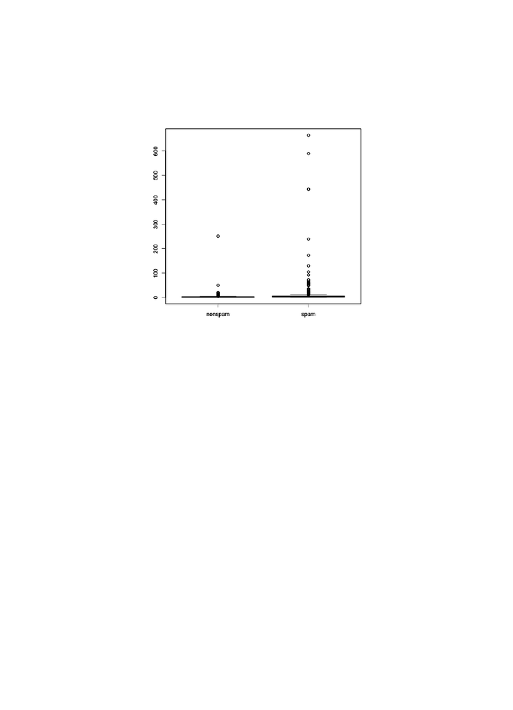

Here we’re looking at a variable called capitalAve, the average number of

capital letters.

boxplot(capitalAve ~ type, data = trainSpam)

Comparison of ‘capitalAve’ between spam

and non-spam emails

And, you can see that it’s difficult to look at this picture, because the data

are highly skewed. And so, in these kinds of situations it’s often useful to

just look at the log transformation of the variable. Here I’m going to to take

the base ten log of the variable, and compare them to spam and nonspam.

Since there are a lot of zeros in this particular variable, taking the log of

zero doesn’t really make sense. We’ll just add 1 to that variable, just so we

can take the log and get a rough sense of what the data look like. Typically,

you wouldn’t want to just add 1 to a variable just because. But since we’re

just exploring the data, making exploratory plots, it’s okay to do that in this

case.

boxplot(log10(capitalAve + 1) ~ type, data = trainSpam)

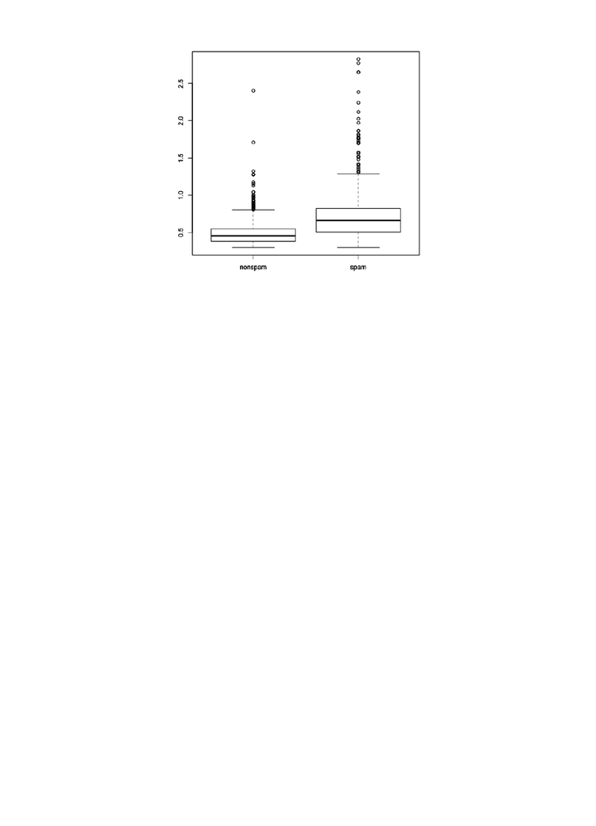

Log transformed ‘captialAve’

Here you can see clearlyb that the spam emails have a much higher rate of

these capital letters than the non spam emails, and of course, if you’ve ever

seen spam emails, you’re probably familiar with that phenomenon. And so

that’s one useful relationship to see there.

We can look at pairwise relationships between the different variables in the

plots. Here I’ve got a pairs plot of the first four variables, and this is the log

transformation of each of the variables.

pairs(log10(trainSpam[, 1:4] + 1))

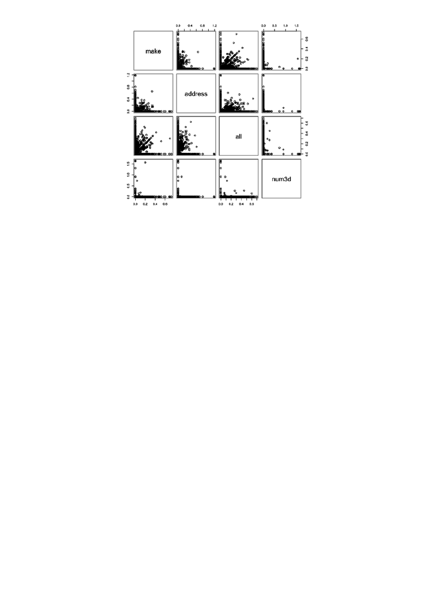

Paris plot of 4 variables

And you can see that some of them are correlated, some of them are not

particularly correlated, and that’s useful to know.

We can explore the predictors space a little bit more by doing a hierarchical

cluster analysis, and so this is a first cut at trying to do that with the hclust

function in R. I plotted the Dendrogram just to see how what predictors or

what words or characteristics tend to cluster together.

hCluster = hclust(dist(t(trainSpam[, 1:57])))

plot(hCluster)

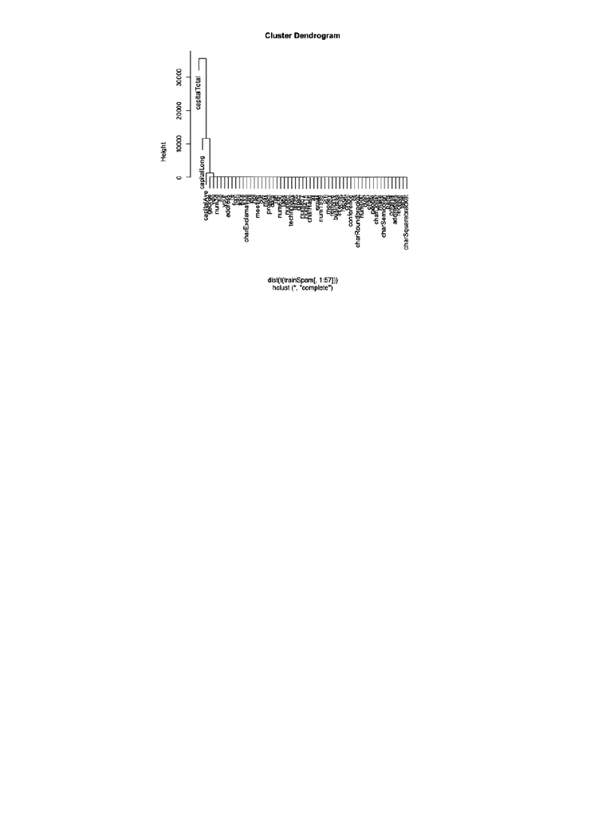

Hierarichal cluster analysis

It’s not particularly helpful at this point, although it does separate out this

one variable, capital total. But if you recall, the clustering algorithms can be

sensitive to any skewness in the distribution of the individual variables, so it

may be useful to redo the clustering analysis after a transformation of the

predictor space.

hClusterUpdated = hclust(dist(t(log10(trainSpam[, 1:55] +\

1))))

plot(hClusterUpdated)

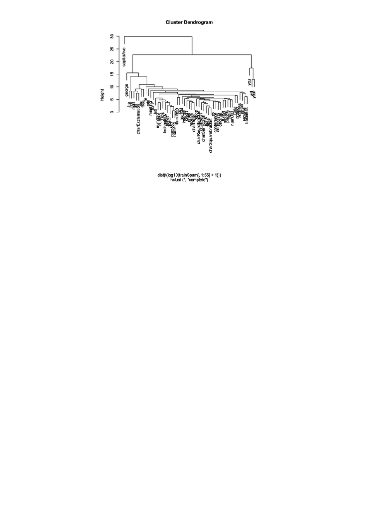

Hierarchical cluster analysis of log-

transformed data

Here I’ve taken a log transformation of the predictors in the training data

set, and again, I’ve added one to each one, just to avoid taking the log of

zero. And now you can see the dendrogram a little bit more interesting. It’s

separated out a few clusters and this captialAve is one kind of cluster all

by itself. There’s another cluster that includes “you will” or “your”. And

then there are a bunch of other words that lump more ambiguously together.

And so this may be something worth exploring a little bit further, if you see

some particular characteristics that are interesting.

Once we’ve done exploratory data analysis, we’ve looked at some

univariate and bivariate plots, we did a little cluster analysis, we can move

on to doing a more sophisticated statistical model and some prediction

modeling. And so any statistical modeling that you engage in should be

informed by questions that you’re interested in, of course, and the results of

any exploratory analysis. The exact methods that you employ will depend

on the question of interest. And when you do a statistical model, you should

account for the fact that the data have been processed or transformed, if

they have, in fact, been so. As you do statistical modeling, you should

always think about, what are the measures of uncertainty? What are the

sources of uncertainty in your data set?

Statistical Modeling

Here we’re going to just do a very basic statistical model. What we’re going

to do is we’re going to go through each of the variables in the data set and

try to fit a generalize linear model, in this case a logistic regression, to see if

we can predict if an email is spam or not by using just a single variable.

Here, using the reformulate function to create a formula that includes the

response, which is just the type of email and one of the variables of the data

set, and we’re just going to cycle through all the variables in this data set

using this for-loop to build a logistic regression model, and then

subsequently calculate the cross validated error rate of predicting spam

emails from a single variable.

trainSpam$numType = as.numeric(trainSpam$type) - 1

costFunction = function(x, y) sum(x != (y > 0.5))

cvError = rep(NA, 55)

library(boot)

for (i in 1:55) {

lmFormula = reformulate(names(trainSpam)[i], response\

= "numType")

glmFit = glm(lmFormula, family = "binomial", data = t\

rainSpam)

cvError[i] = cv.glm(trainSpam, glmFit, costFunction, \

2)$delta[2]

}

## Which predictor has minimum cross-validated error?

names(trainSpam)[which.min(cvError)]

[1] "charDollar"

Once we’ve done this, we’re going to try to figure out which of the

individual variables has the minimum cross validated error rate. And so we

can just go, and you can take this vector of results, this CV error, and just

figure out which one is the minimum.

It turns out that the predictor that has the minimum cross validated error

rate is this variable called charDollar. This is an indicator of the number of

dollar signs in the email. Keep in mind this is a very simple model. Each of

these models that we fit only have a single predictor in it. Of course we

could think of something more complicated, but this may be an interesting

place to start.

If we take this best model from this set of 55 predictors, this charDollar

variable, and I’ll just re-fit the model again right here. This is a logistic

regression model. We can actually make predictions now from the model on

the test data. Recall that we split the data set into two parts and built the

training model on the training data set. Now we’re going to predict the

outcome on the test data set to see how well we do.

In a logistic regression we don’t get specific 0/1 classifications of each of

the messages, we get a probability that a message is going to be spam or

not. Then we have to take this continuous probability, which ranges

between 0 and 1, and determine at what point, at what cutoff, do we think

that the email is spam. We’re just going to draw the cut off here at 0.5, so if

the probability is above 50%, we’re just going to call it a spam email.

## Use the best model from the group

predictionModel = glm(numType ~ charDollar, family = "bin\

omial", data = trainSpam)

## Get predictions on the test set

predictionTest = predict(predictionModel, testSpam)

predictedSpam = rep("nonspam", dim(testSpam)[1])

## Classify as `spam' for those with prob > 0.5

predictedSpam[predictionModel$fitted > 0.5] = "spam"

Once we’ve created our classification, we can take a look at the predicted

values from our model, and then compare them with the actual values from

the test data set, because we know which was spam, and which was not.

Here’s the classification table that we get from the predicted and the the real

values.

table(predictedSpam, testSpam$type)

predictedSpam nonspam spam

nonspam 1346 458

spam 61 449

Now we can just calculate the error rate. The mistakes that we made are on

the off diagonal elements of this table, so 61 and 458. So, 61 were classified

as spam that were not actually spam, and 458 were classified as non spam

but actually were spam. So we calculate this error rate as about 22%.

## Error rate

(61 + 458)/(1346 + 458 + 61 + 449)

[1] 0.2242869

Interpreting Results

So far we’ve done the analysis, calculated some results, calculated our best

model, and looked at the error rate that’s produced by that model. Now we

need to interpret our findings and it’s important when you interpret your

findings to use appropriate language and to not use language that goes

beyond the analysis that you actually did. If you’re in this type of

application where we’re just looking at some data and building a predictive

model, you want to use words like, “prediction” or “it correlates with” or

“certain variables may be associated with the outcome” or “the analysis is

descriptive”. Think carefully about what kind of language you use to

interpret your results. It’s also good to give an explanation for why certain

models predict better than others, if possible.

If there are coefficients in the model that you need to interpret, you can do

that here. And in particular it’s useful to bring in measures of uncertainty, to

calibrate your interpretation of the final results. In this example, we might

think of stating that the fraction of characters that are dollar signs can be

used to predict if an email is spam. Maybe we decide that anything with

more than 6.6% dollar signs is classified as spam. More dollar signs always

means more spam under our prediction model. And for our model in the test

data set, the error rate was 22.4%.

Challenge the Findings

Once you’ve done your analysis and you’ve developed your interpretation,

it’s important that you, yourself, challenge all the results that you’ve found.

Because if you don’t do it, someone else is going to do it once they see your

analysis, and so you might as well get one step ahead of everyone by doing

it yourself first. It’s good to challenge everything, the whole process by

which you’ve gone through this problem. Is the question even a valid

question to ask? Where did the data come from? How did you get the data?

How did you process the data? How did you do the analysis and draw any

conclusions?

If you have measures of uncertainty, are those the appropriate measures of

uncertainty? And if you built models, why is your model the best model?

Why is it an appropriate model for this problem? How do you choose the

things to include in your model? All these things are questions that you

should ask yourself and should have a reasonable answer to, so that when

someone else asks you, you can respond in kind.

It’s also useful to think of potential alternative analyses that might be

useful. It doesn’t mean that you have to do those alternative analyses, in the

sense that you might stick to your original just because of other reasons.

But it may be useful to try alternative analyses just in case they may be

useful in different ways or may produce better predictions.

Synthesizing Results

Once you’ve interpreted your results, you’ve done the analysis, you’ve

interpreted your results, you’ve drawn some conclusions, and you’ve

challenged all your findings, you’re going to need to synthesize the results

and write them up. Synthesis is very important because typically in any data

analysis, there are going to be many, many, many things that you did. And

when you present them to another person or to a group you’re going to want

to have winnowed it down to the most important aspects to tell a coherent

story. Typically you want to lead with the question that you were trying to

address. If people understand the question then they can draw up a context

in their mind, and have a better understanding of the framework in which

you’re operating. That will lead to what kinds of data are necessary, are

appropriate for this question, what kinds of analyses would be appropriate.

You can summarize the analyses as you’re telling the story. It’s important

that you don’t include every analysis that you ever did, but only if its

needed for telling a coherent story. It’s useful to sometimes keep these

analyses in your back pocket though, even if you don’t talk about it,

because someone may challenge what you’ve done and it’s useful to say,

“Well, you know we did do that analysis but it was problematic because of”

whatever the reason may be.

It’s usually not that useful to talk about the analyses that you did

chronologically, or the order in which you did them, because the order in

which you did them is often very scattered and doesn’t make sense in

retrospect. Talk about the analyses of your data set in the order that’s

appropriate for the story you’re trying to tell. When you’re telling the story

or you’re presenting to someone or to your group it’s useful to include very

well done figures so that people can understand what you’re trying to say in

one picture or two.

In our example, the basic question was “Can we use quantitative

characteristics of the emails to classify them as spam or ham?” Our

approach was rather than try to get the ideal data set from all Google

servers, we collected some data from the UCI machine learning repository

and created training and test sets from this data set. We explored some

relationships between the various predictors. We decided to use a logistic

regression model on the training set and chose our single variable predictor

by using cross validation. When we applied this model to the test set it was

78% accurate. The interpretation of our results was that basically, more

dollar signs seemed to indicate an email was more likely to be spam, and

this seems reasonable. We’ve all seen emails with lots of dollar signs in

them trying to sell you something. This is both reasonable and

understandable. Of course, the results were not particularly great as 78%

test set accuracy is not that good for most prediction algorithms. We

probably could do much better if we included more variables or if we

included a more sophisticated model, maybe a non-linear model. These are

the kinds of things that you want to outline to people as you go through data

analysis and present it to other people.

Reproducible Code

Finally, the thing that you want to make sure of is that you document your

analysis as you go. You can use things like tools like R Markdown and knitr

and RStudio to document your analyses as you do them (more about this in

later chapters). You can preserve the R code as well as any kind of a written

summary of your analysis in a single document using knitr. And so then to

make sure that all of what you do is reproducible by either yourself or by

other people, because ultimately that’s the standard by which most big data

analysis will be judged. If someone cannot reproduce it then the

conclusions that you draw will be not as worthy as an analysis where the

results are reproducible. So try to stay organized. Try to use the tools for

reproducible research to keep things organized and reproducible. And that

will make your evidence for your conclusions much more powerful.

[figure not shown]

8. Markdown

Markdown is a tool for writing for the web. In the words of its creator John

Gruber

“Markdown is a text-to-HTML conversion tool for web writers.

Markdown allows you to write using an easy-to-read, easy-to-write

plain text format, then convert it to structurally valid XHTML (or

HTML).”

Since its inception, Markdown has evolved to be widely adopted for a

variety of purposes, far beyond writing for the web. In particular, the book

you are reading was written in Markdown.

The name “Markdown” is a play on the names of of many “markup”

languages. Its key feature is that it can be read as-is, without any special

formatting. Many markup languages, like HTML or LaTeX, require that

numerous formatting elements (tags) be included in the text to instruct the

program that will be formatting the text for reading on how to display the

text. While this gives great control over the look and feel of the text to the

writer, it can greatly obscure the source text itself, making the text difficult

to read and edit. With HTML, some of the tag clutter was removed with the

use of cascading style sheets (CSS), but there is still quite a bit of clutter in

most HTML documents.

The benefit of Markdown for writers is that it allows one to focus on

writing as opposed to formatting. It has simple and minimal yet intuitive

formatting elements and can be easily converted to valid HTML (and other

formats) using existing tools.

Complete information about Markdown is available at the Markdown web

site maintained by John Gruber. You’ll notice that the web page is short.

There’s not much to describe! There’s also some background information

about Markdown at Gruber’s site.

[figure not shown]

What is R Markdown?

R markdown is the integration of R code with Markdown. Documents

written in R Markdown have R coded nested inside of them, which allows

one to to create documents containing “live” R code. R Markdown files

cannot be evaluated using standard Markdown tools. Rather, R code is

evaluated as part of the processing of the Markdown before the traditional

Markdown tools are called.

R markdown can be converted to standard markdown using the knitr

package in R. Results from R code are inserted into Markdown document.

Markdown can subsequently be converted to HTML using the markdown

package in R, but you seldom have to call this package explicitly.

The use of R Markdown to create reproducible reports is now a core tool in

literate statistical programming and has largely replaced previous tools.

The key reason for its usefulness is the simplicity of Markdown as the main

documentation language, the powerful support provided by the knitr

package, and the integration of R Markdown into widely used products like

RStudio.

One co-benefit of using R Markdown is that any basic text editor can be

used to create a document. No special editing tools are needed (the editor

that comes with RStudio, for example, is quite reasonable). The R

Markdown to Markdown to HTML work flow can be easily managed using

R Studio (but is not required). Lastly, R Markdown documents have the

benefit that they are purely textual documents that can play well with

version control systems that are primarily designed to track changes in text

files.

Markdown Syntax

Markdown has a very simple syntax that we will briefly review here.

Headings

# This is a primary heading (think <h1> in HTML)

## This is a secondary heading

### This is a tertiary heading

Italics

*This text will appear italicized!*

_so will this text_

This text will appear italicized!

so will this text

Bold

**This text will appear bold!**

__as will this text__

This text will appear bold!

as will this text

Unordered Lists

- first item in list

- second item in list

- third item in list

first item in list

second item in list

third item in list

Ordered Lists

1. first item in list

2. second item in list

3. third item in list

1. first item in list

2. second item in list

3. third item in list

Note that you don’t have to worry about the specific ordering of the

numbers in the ordered list. As long as there are numbers there, Markdown

will put them in the right order.

The following Markdown source

[figure not shown]

1. first item in list

2. second item in list

4. Whoops! Forgot one

3. third item in list

will get processed as

1. first item in list

2. second item in list

3. Whoops! Forgot one

4. third item in list

Links

Inline links can be formatted with the following syntax.

The number one school of the public health is the [Johns \

Hopkins Bloomberg School of Public Health](http://www.jhs\

ph.edu/).

The first thing you always want to do is [Download R](htt\

p://www.r-project.org/).

The second thing you want to do is get [RStudio](http://w\

ww.rstudio.com/).

The number one school of the public health is the Johns Hopkins

Bloomberg School of Public Health.

The first thing you always want to do is Download R.

The second thing you want to do is get RStudio.

Occasionally, have to put so many links into a document that the document

starts getting difficult to read because of all the URLs. In that case, there is

an alternate approach to linking that is akin to inserting footnotes.

I spend so much time reading [R bloggers][1] and [Simply \

Statistics][2]!

[1]: http://www.r-bloggers.com/ "R bloggers"

[2]: http://simplystatistics.org/ "Simply Statistics"

I spend so much time reading R bloggers and Simply Statistics!

[figure not shown]

In the above text, the full links can be placed at the bottom of a document

for convenience. The resulting formatted text is identical using both

approaches, however, the source text will be easier to read because it is less

cluttered.

Newlines

Newlines require a double space after the end of a line.

If you just hit “enter/return” at the end of a line this is what you get.

First line

Second line

First line Second line

However, if you put two spaces after the end of the first line, this is what

youget.

First line

Second line

First line

Second line

Markdown Resources

The Offical Markdown Documentation

Github’s Markdown Guide

9. Using knitr for Reproducible Reports

There are a number of challenges to making reproducible report writing a

reality. Authors must undertake considerable effort to put data and results

on the web or at least to make them available to a wide audience. Readers

must download those data and results individually and piece together which

data go with which code sections. Often both authors and readers must

manually interact with websites, in a highly non-automated process. Finally,

there is often no single document to integrate data analysis with textual

representations, so the data, code, and text are not linked together in a

coherent manner.

A general solution that attempts to address some of these challenges is

literate statistical programming, a concept we introduced earlier in this

book. For those of you who are skipping around, the idea of literate

programming comes from Donald Knuth, who envisioned computer code

and the documentation for that code existing together in a single document.

For literate statistical programming, the idea is that a report is viewed as a

stream of text and code. Analysis code is divided into code chunks with text

surrounding the code chunks explaining what is going on. In general,

literate programs are weaved to produce human-readable documents and

tangled to produce machine- readable documents

The requirements for writing literate programs are a documentation

language and a programming language. Knuth’s original WEB system

used TeX as the documentation language and Pascal as the programming

language. Fritz Leisch originally developed the Sweave system for R,

which used LaTeX as the documentation language and R as the

programming language. This system was very powerful, and quite useful

for those mathematically and statistically inclined users for whom LaTeX

was a commonly used markup language. However, the requirement to learn

LaTeX was a high barrier for mamy people, higher even than learning R, if

only because people saw few benefits to learning LaTeX except to use a

system like Sweave. Sweave still comes with every R installation and is

maintained by the R Core members.

Literate Statistical Programming: Pros and Cons

Before we go on to the details of using knitr for reproducible reports, we

should note that there are both advantages and disadvantages to using a

literate programming system for writing reports. Some of the advantages

are that

Text and code are all in one place and placed in a logical order as

dictated by the flow of the data analysis

Results are automatically updated to reflect external changes to data,

code, etc.

Code is live; this helps to serve as a built in regression test when

building a document—if you can’t run the code, you can’t build the

document.

On the other hand, there are some disadvantages:

Text and code all in one place! This can sometimes make documents

difficult to read, especially if there is a lot of code. It might make sense

to place code in a separate file, but they you are introducing more

complexity and more chances for non-reproducibility.

The processing of documents can be very slow, especially if the

document is long. However, there are now tools that can help with that

(somewhat). In general, literate statistical programming tools are

awkward to use for very long or very complex documents. In those

cases, it’s better to use literate programming tools in conjunction with

other tools, like Makefiles.

My general feeling is that knitr is ideal for

Manuals

Short/medium-length technical documents

Tutorials

Reports, especially if they will be generated periodically with updated

data

[figure not shown]

Data preprocessing documents and summaries

I feel that knitr is NOT particularly well-suited for the following:

Very long research articles

Documenting very complex and time-consuming computations

Documents that require precise formatting (although this is more an

issue with using Markdown than it is with using knitr)

The knitr Packages

The knitr package was developed by Yihui Xie, while he was a graduate

student at Iowa State University. The knitr package many of the ideas that

had been developed in separate packages since the introduction of Sweave

and combined them all together into one logical package/framework. The

package supports a variety of documentation languages (Markdown,

LaTeX, and HTML) and a variety of programming languages. The package

also supports weaving to PDF and HTML formats (in RStudio you can also

weave to Microsoft Word docx format). For the purposes of this book, we

will focus on using Markdown as the documentation language and R as the

programming language and assume you are exporting to HTML format.

The knitr package is available from your local CRAN mirror and can be

installed with the install.packages() function in R. One key feature of

the RStudio IDE (among many) is that knitr is built right into the GUI so

that you can write documents with knitr without having to write at the

console.

To use the knitr package, you need

A recent version of R

A text editor for writing R Markdown documents (the one that comes

with RStudio is fine)

Some support packages installed (also available on CRAN)

Some knowledge of Markdown, LaTeX, or HTML

As noted above, we will focus on using Markdown here.

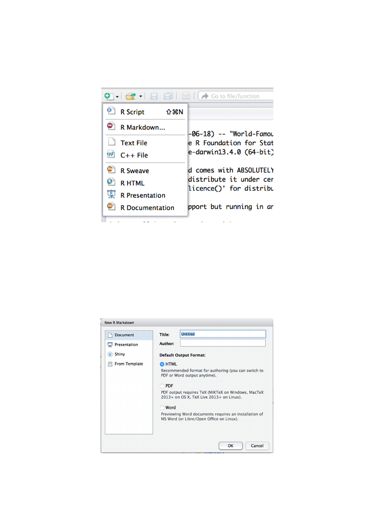

My First knitr Document

Here’s an example of creating a simple R Markdown document in RStudio.

To create a new document, you can click on the menu in the upper left hand

side of the GUI.

Open an R Markdown Document

RStudio will prompt you with a dialog box to set some of the metadata for

the document. You can feel free to either fill this out now or just click OK.

Either way, you can always make changes to this information later.

Initial Configuration Options

Initially, RStudio creates the R Markdown document with some filler text.

Don’t worry about this text, you can feel free to delete later it when you’re

[figure not shown]

ready to write your document. However, if you’re new to R Markdown, you

might want to take a look at it to get a feel of how R Markdown documents

are written.

Initial Document with Boilerplate Text

Processing an R Markdown Document

When you are ready to process and view your R Markdown document the

Use the “Knit HTML” Button

If you’re not using RStudio, you can still process R Markdown documents

with the knitr package directly. Assuming your R Markdown document is

in your current working directory (as determined by getwd()) you can run

library(knitr)

knit2html("document.Rmd")

browseURL("document.html")

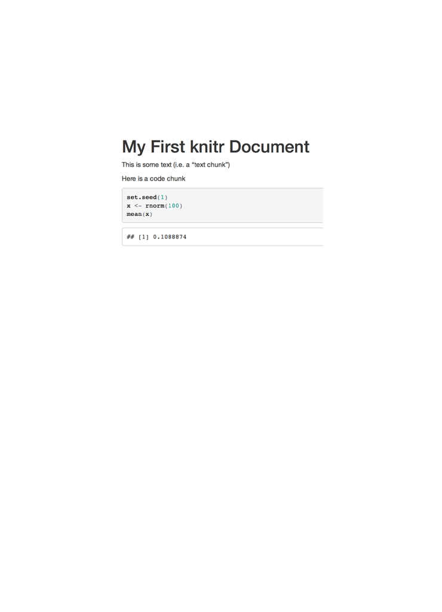

where document.Rmd and document.html should be substituted with

whatever your file name happens to be.

HTML Output

the result you get should look something like this.

Initial HTML Output

Note here that the the code is echoed in the document in a grey background

box and the output is shown just below it in a white background box. This

is the default theme for the output in RStudio. For better or for worse,

knitr produces (by default) a standalone HTML document with the styling

information built in to the document.

Notice also that the output is prepended with two pound symbols. This is

there so that if you happen to be copying code from the HTML output and

pasting it into the R console, you just copy and paste the code and don’t

accidently paste the output too (the output will be commented out in the R

console). You can turn this behavior off by setting

knitr::opts_chunk$set(comment = NA)

at the top of your document somewhere (see below for setting global

options).

A Few Notes

There are a couple of things worth noting at this point. First, as you already

saw, opening a new R Markdown document in RStudio will fill a new

document with filler text. Just delete the filler; it’s just there to demonstrate

the basics of R Markdown documents.

Code chunks begin with ```{r} and end with just ```. Any R code that you

include in a document must be contained within these delimiters, unless you

have inline code. Code chunks can have names, which is useful when we

start incorporating graphics (graphics file names are based on the code

chunk name). Finally, by default, code in a code chunk is echoed back out

to the document, as will the results of the computation (if there are results to

print).

When you process a knitr document here’s what happens under the hood:

1. You write the RMarkdown document (with a .Rmd extension)

2. knitr produces a Markdown document (with a .md extension)

3. knitr converts the Markdown document into HTML (by default)

The process is .Rmd to .md to .html; in principle there should be three

documents when the process is complete, but RStudio deletes the

intermediary .md file by default (you can turn this behavior off if you need

the .md file)

You should NOT edit (or even save) the .md or .html documents until you

are finished; these documents will be overwritten the next time you knit the

.Rmd file.

Another Example

Here’s an example of an R Markdown document where we modify some of

the chunk-level arguments to override the defaults. In this case, we choose

to NOT echo the code in the resulting document. This sometimes useful if

there’s just too much code and you don’t want to overwhelm the reader with

a print out of the code.

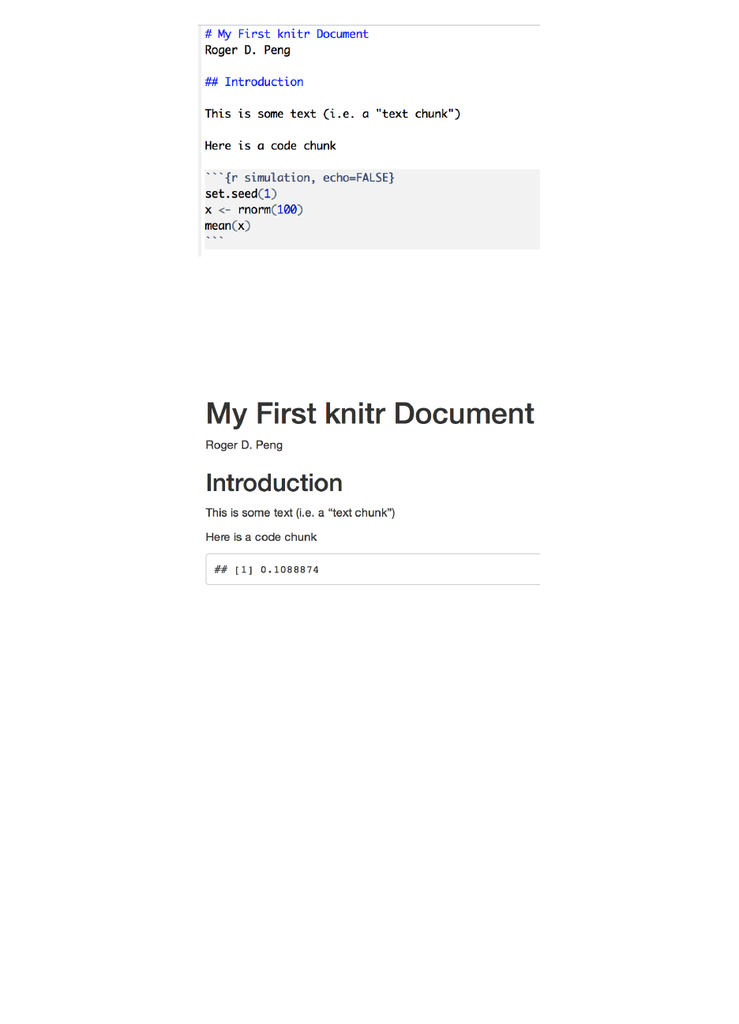

Another R Markdown Example

And here is the output.

Hiding Source Code

Notice that now the code is no longer in the document.

Hiding Results

In addition to hiding the code, you can hide the results of computation. This

is sometimes useful if you are, for example, making a plot and you want the

reader to see the final plot, not the various results of the computations that

came before it. Setting the option results = "hide" achieves this.

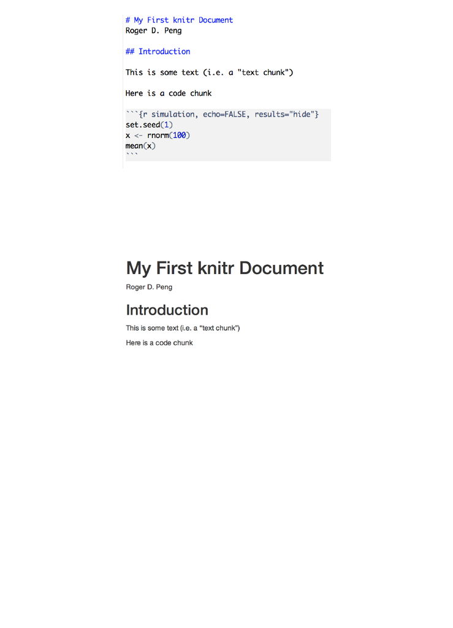

Hiding Results

The following output now hides both the code and the results of the code.

Output With Hiding Results

Inline Computations

Occasionally, it’s useful to put some computations within a sentence. For

example, you may be quoting a specific numerical results in the middle of a

paragraph. Rather than try to copy and paste the result into the paragraph,

it’s better to just do the computation right there in the text.

In this example I’m quoting the current time and generating a random

Normal variate as my “favorite” number.

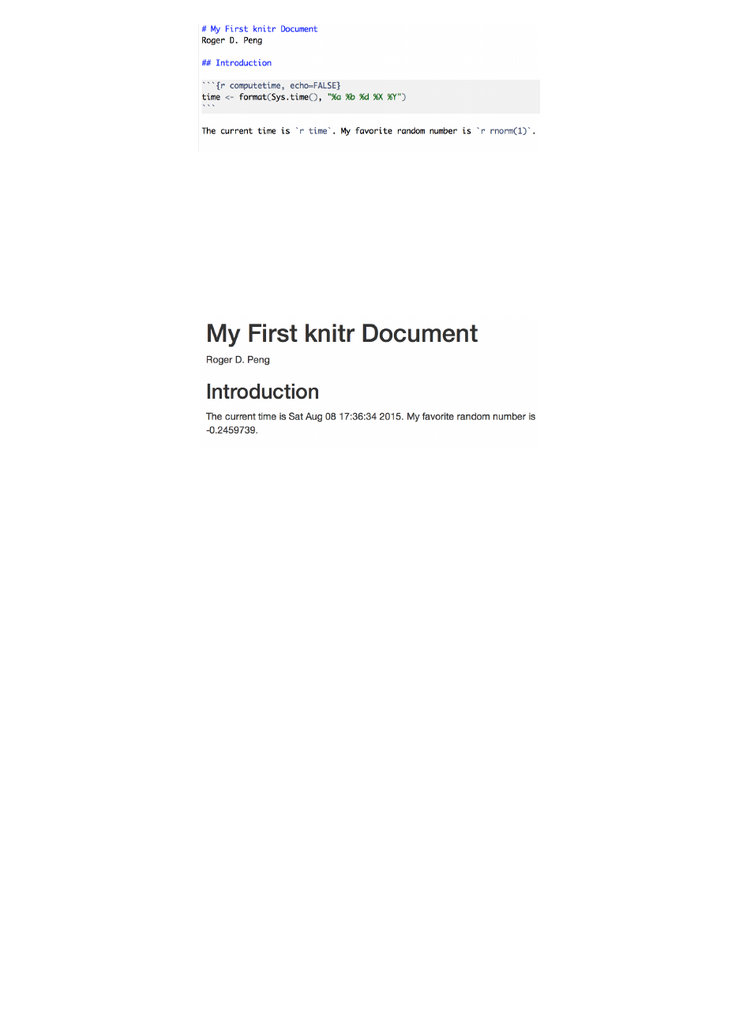

Inline Computation

Here is the output from the above source. Notice that the current time is

inserted into the text, as well as a random number.

Inline Computation Output

Incorporating Graphics

No report of a data analysis would be complete without some sort of

graphic or plot, right? Of course, incorporating data graphics with knitr is

straightforward. By default, nothing special needs to be done. You can just

put the plotting code in a code chunk and the plot will be inserted into the

resulting HTML document.

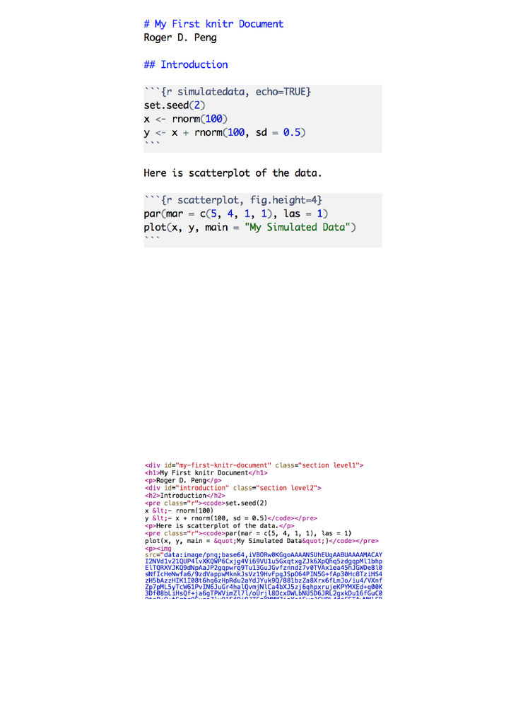

Creating Plots

In the example above, I decided to change the figure height to make it a bit

shorter than the default. You can change the width of the plot with the

fig.width argument in the code chunk.

When knitr creates the HTML document, by default, it embeds the figure

into the HTML document as base 64 encoded string. You can see that here

in the HTML below.

Generated HTML

This is useful sometimes because it makes the resulting HTML document

stand alone. You can email it to a colleague and they will be able to view it

without having to worry about any external dependencies like image files.

However, it does make the resulting HTML much larger than it needs to be

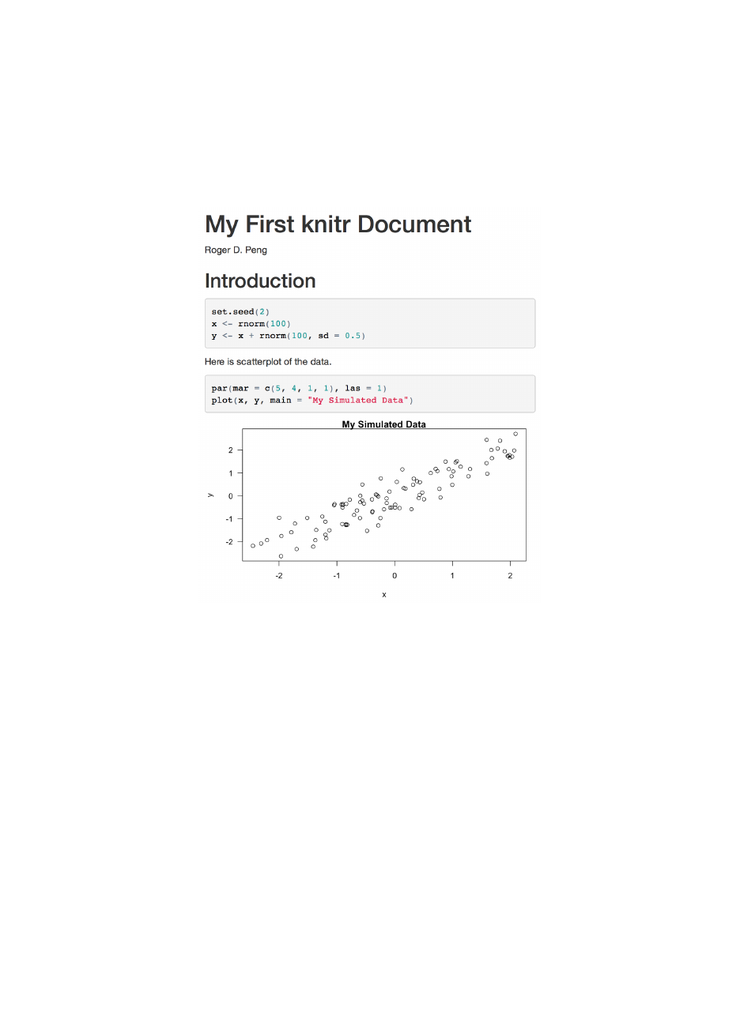

(and make sit totally unreadable). That said, given that the HTML is not

meant to be read directly and is just auto-generated by knitr, it’s not clear

that there are many downsides to this approach.

Here’s the actual output that gets rendered in the HTML viewer (or web

browser).

Creating Plots

Making Tables With xtable

Tables can be made in R Markdown documents with the help of the xtable

package. Tables can be notoriously non-reproducible if they are made by

hand. Luckly, the xtable package can take tabular information and format

it nicely in either HTML or LaTeX. Here, we will create HTML tables.

In the code below, we fit a multiple linear regression model and then create

a table of the regression coefficients. Essentially, this is the output that is

generated by the summary() function when called on lm objects.

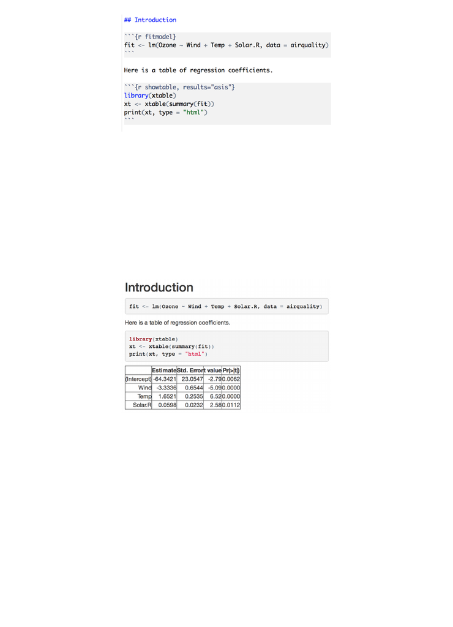

Making Tables with xtable

Notice that in the chunk options I specify results="asis". This is because

xtable generates its own HTML output, so it doesn’t have to be

subsequently converted into HTML by knitr.

The output document is below.

Table Output from xtable

This is just one simple example of how xtable can be used to generate

HTML tables. There are many other options that can be configured in the

print() method for xtable objects and the help page is worth exploring.

Setting Global Options

Sometimes you want to set an option that applies to all chunks in your

document. This can be done by modifying the opts_chunk variable in

knitr, which is a global variable in the knitr package. Usually, this is done

by creating a code chunk somewhere in the beginning of the document

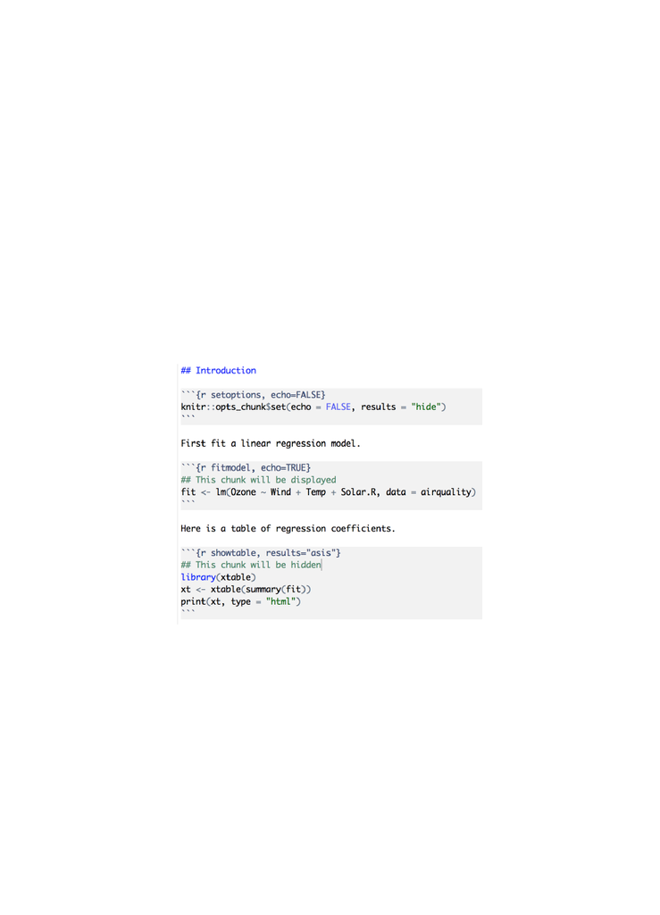

(before any other code chunks in the document) and modifying the

opts_chunk object.

For example, if we wanted the default to be that all chunks do NOT echo

their code and always hide their results, we could set

knitr::opts_chunk$set(echo = FALSE, results = "hide")

Any other valid chunk options can be set in the embedded set() function in

the opts_chunk object.

Global options can always be overridden by any specific options that are set

in at the chunk level. For example, when using the xtable package, I want

to override the default results argument.

Setting Global Options

Here is the corresponding output.

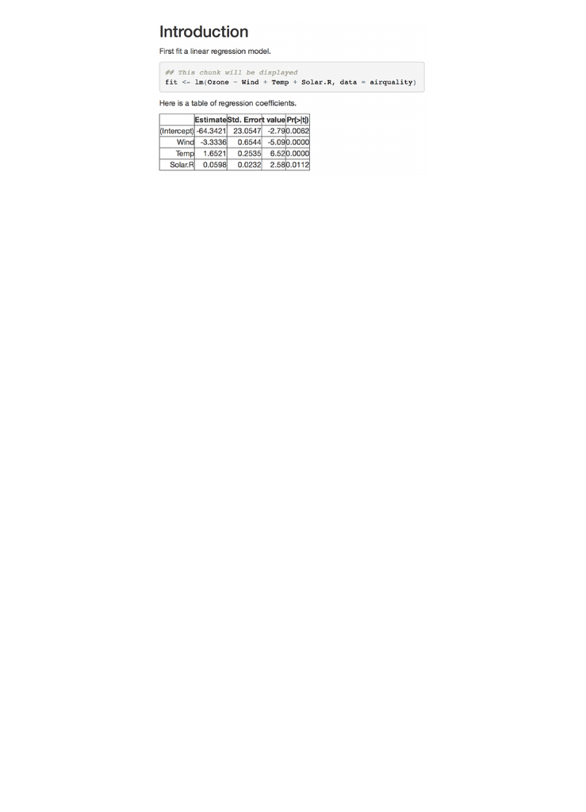

Global Options

Caching Computations

Earlier in this chapter, I mentioned that knitr is perhaps not so useful if

you are writing a very long document or one involving complex

computations. However, there is one tool that can be useful and may help

you circumvent some of these problems.

The basic issue is that if you have a long document or one involving

lengthy computations, then every time you want to view your document in

the pretty formatted version, you need to re-compile the document, meaning

you need to re-run all the computations. If your code chunks are quick and

not too numerous, the having to knit the document every time is not such a

burden. But otherwise, it can be painful to have to sit there and wait for

every computation to run every single time.

Chunk caching is one way to avoid these lengthy computations. By setting

the cache = TRUE chunk option, what knitr does is run the chunk once,

then store the output in a database in your working directory. Then, when

you re-knit the document, instead of running the code in that particular

chunk, knitr simply re-loads the stored output from the database. It’s kind

of like a chunk-level version of memoization. However, if the code in the

chunk changes at all, knitr can detect this and will re-run the code (and

store the reuslts again).

There some caveats to caching. In particular, by default dependencies

between chunks are not checked. If the results of a cached chunk depend on

a previous chunk that has been modified, those changes will not necessarily

propogate down to later cached chunks. Also, chunks with significant side

effects, such as those writing output to files or interacting with the external

environment in any way, may not be cacheable.

Summary

Literate statistical programming can be a useful way to put text, code, data,

and output all in one document. Doing this with R and Markdown, in

conjuncdtion with the knitr package and RStudio, is an very easy and yet

powerful tool for integrating code and text in a simple document format.

10. Communicating Results Over E-mail

A substantial and important part of any good data analysis involves

communicating the results to others. While communication may involve

writing a report, publishing a paper, or making an oral presentation, in many

settings the initial “presentation” is through e-mail or something similar. In

in the background. This chapter talks about ways in which you can organize

presentations so that various types of people (e.g. managers, colleagues) can

extract as much useful information out as possible.

This chapter is not so much about reproducibility per se. It’s more about

how you can communicate your results in a way that people can understand

them and can check or challenge your results, if they need to. Particularly,

when you’re working on a large data analysis, or a complex project, and

you do your work in a reproducible manner, you’re going to generate a lot

of content, files, output, and data. These outputs cannot all be presented at

once without any structure.

When you present your findings to another person there’s a hierarchy of

information that you’re going to want to present, ranging from the least

specific to most specific. The bottom line is that most people these days are

very busy. People like managers and organization leaders are going to be

very busy, so they are more likely to accept and digest content that you

present in a streamlined and hierarchical order.

Many times when you present a data analysis, it will be in an oral form like

a presentation or in a meeting. Often the early results or intermediate results

are presented via a medium like e-mail. It’s useful to break down the results

of an analysis into different levels of specificity or granularity. The basic

idea is that you don’t want to blast a ton of information to someone in one

go, because it’ll be overwhelming and people will be less likely to read

what you have to say.

Hierarchy of a Research Paper

If you think about what a typical research paper might look like, it’s a

hierarchy of information built into a research paper.

1. Title and Author list: Typically the first level is going to be the title,

which is descriptive of what the paper’s about. Hopefully it’s

interesting, it tells you a little bit about what’s going on, but there’s

really no detail in a title, just the the topic that’s covered. Also, we can

learn who is responsible for the work from the author list.

2. Abstract: The next will be the abstract, usually a couple hundred

words, describing what the paper’s about, what motivated the problem

and what was done to solve the problem.

3. Body and Results: Then, of course, you have the paper itself. The

body of the paper will have the methods and more details about what

you really did. The more detailed results will include any sensitivity

analyses and a much longer discussion of the implications of the

results.

4. Supplementary materials (gory details): Of course, even the written

paper, for a complex data analysis, doesn’t specify all the details that

are needed to reproduce the findings. Typically, you might have some

supplementary materials which have a lot more of the details about

what was done.

5. Code and data (really gory details): If you really want to do what

was done to a level of precision that is useful, you probably need to get

the code, the data and all the gory details of what happened.

That’s the range of things that you might be able to present from least

specific to most specific in a typical research paper.

Hierarchy of an E-mail

Not everyone is writing a research paper, but there is an analog: e-mail. If

you’re going to be e-mailing results either a colleague or a manager, then

it’s a good idea to follow a basic structure:

1. Subject Line and Sender Information: First line of information is

the subject of the e-mail, which becomes like the title. It should be

concise, you want to be descriptive, and at a minimum, you want to

have one. So don’t send an e-mail without a subject, it’s not specific as

to what the e-mail is about. If you can summarize what you’ve done in

one sentence, it may be useful put that in the subject. That way people

reading the subject can get a sense of what’s happening and maybe

even make a decision based on that alone.

2. E-mail Body: The next level of information is the e-mail body. Even

though there’s no technical limit on the size of the e-mail body, you

don’t want to go too crazy with this. You need to provide a brief

is or precisely what you’re working on. Give them a little context, give

them a little description. Recall if there was a dsicussion previously.

Talk about what was proposed and what you actually did. Summarize

some of your findings and your results for one to two paragraphs

within the e-mail body. If you need the person to take some sort of

action based on the results of this presentation, try to suggest some

options that and make them as concrete as possible. If there are

questions that need to be addressed, it’s best to make them yes/no

questions, or as simple as possible.

3. Attachments: After the e-mail body you might attach something that’s

quite a bit longer, a PDF file or another type of document. This can be

a report containing more detailed analyses, figures, tables, things like

that. This can be derived from an R markdown file. You can use

something you create with knitr. Even in the report like this where

you may be allowed acouple of pages to present things, you still want

to stay concise, you don’t want to spit out pages and pages of code and

tables and results. We know that your code is available because if you

use something like knitr then obviously, you have to put the code in

with the results, but you don’t necessarily have to present it all in the

report.

4. Supplementary Materials: If someone really wants to look at what

you did precisely, you can give them a link to a repository, like

GitHub, a project website that would have all of the details, or all your

code files, all your data sets, your software environment, things like

that. Those are the different levels of detail that you might want to

present to someone.

There may be many different kinds of people with different levels of

interest in your work who are reading the e-mail you send out. People who

are truly interested in everything that you did or really want to know the

details, they might go to your GitHub repository and start pulling your code

and start looking at the detailed results. Conversely, someone who wants

top line summaries will read the e-mail, look at the subject, read the brief

description, and maybe flip through the report.

You want to present people with these different levels of detail so they can

choose the level that they are most interested in. This is just a generic

template for how you might present an analysis or a data, or a project that

you’ve worked on. Not every presentation will need all these different

levels but I find this to be a useful breakdown of the different types of

presentations that you can make.

11. Reproducibility Check List

Reproducibility can be more or less easy to achieve depending on the

context, the scientific area, the complexity of a data analysis, and a variety

of other factors. However, over time, I’ve developed a few rules of thumb

that I think are useful for at least encouraging reproducibility, if not

guaranteeing it. In this chapter, I put together a simple “check list” of ideas

that I’ve developed in my experience doing data analysis and computational

research.

Start With Good Science

Good science, generally speaking, or a good question, is the key to any

worthwhile investigation. The general rule of “garbage in, garbage out”

applies here. If you do not start with a meaningful question, then no amount

of data analysis or statistical machinery will be able to make the results

interesting to you. If the question and the results are not interesting to you

or your colleagues, there will be relatively little motivation to make the

results reproducible. This is a problem.

Having a coherent, focused question simplifies many problems and will

make it easier to determine whether you are on the right track or if an error

has occurred. Vague and broadly defined questions can fit many different

scenarios and are more likely to encourage sloppiness and unclear thinking.

Related to working on a problem that interests you is working with good

collaborators. Collaborators that you work well with will reinforce good

practices and will encourage you to do the best work. Ultimately, if you are

uncomfortable with the people you are working with, or more seriously, if

you do not completely trust the people you are working with, then there

will be breakdowns in communication and things will get lost. If you don’t

feel comfortable (politely) challenging a colleague’s work when needed,

then bad work will make it through, which can lead to non-reproducible

results. Working with the right people is an important, but often

unmentioned, aspect of making work reproducible.

Don’t Do Things By Hand

If this chapter could be boiled down to one rule, it might be “Don’t do

things by hand”. What do I mean by that? Here are a few examples that are

common, but are bad practice:

Editing spreadsheets of data to “clean it up”. Often this is doen to

remove outliers, do quality assurance or quality control checks

(QA/QC), or validating individual data entries

Editing tables or figures (e.g. rounding, formatting) to make then look

better

Downloading data from a web site using a web browser

Moving data around your computer

Splitting or reformatting data files

Often, the motiviation for doing all of the above things is that “We’re just

going to do this once.” The thinking is that if the activity is only going to be

done once, it doesn’t need to be automated (i.e. programmed into a

computer).

But programming a procedure into a computer is not necessarily about

automation. It is also about documentation. The problem with things that

are done by hand, is that things done by hand need to be precisely

documented (this is harder than it sounds). Often, it can very difficult to

communicate to someone what was done after the fact. It can be easy to

miss a step that “isn’t important” when in fact it is.

Don’t Point And Click

Pointing and clicking is obviously related to doing things by hand. Most

modern operating systems have a windowing interface that allow you to

click on menus that can lead to automated built-in routines. Many data

processing and statistical analysis packages have graphical user interfaces

(GUIs) that simplify the use of the program, but the actions you take with a

GUI can be difficult for others to reproduce because there’s not necessarily

a log of what was clicked.

Some GUIs for statistical analysis packages produce a log file or script

which includes equivalent commands for reproducing the behavior of the

GUI, but this is by no means the standard. In general, be careful with data

analysis software that is highly interactive. There is often a trade-off

between the ease of use of a software package and the tendency to lead to

non-reproducible results.

Of course, this doesn’t mean that all interactive software. Some software

has to be interactive, like text editors or word processors, and that’s fine.

It’s just when the software must be used to conduct data analysis, you must

be careful not to be seduced by the ease-of-use of an interactive interface.

Teach a Computer

The opposite of doing things by hand is teaching a computer to do

something. Computers need very precise instructions to accomplish a task

so there’s no room for ambiguity. This is a Good Thing if your goal is to

make your procedures and processes reproducible. If something needs to be

done as part of your analysis or investigation, try to teach your computer to

do it, even if you only need to do it once. In the end, teaching a computer to

do something almost guarantees reproducibilty.

Example: Downloading data

Downloadling datasets is something data scientists are constantly doing.

But if you’re using a web browser to download data, you’re probably not

downloading data in a reproducible way. Suppose you wanted to obtain a

dataset to analyze from the UCI Machine Learning Repository. One way to

do that by hand would be to

1. Go to the UCI Machine Learning Repository at

http://archive.ics.uci.edu/ml/

2. Download the Bike Sharing Dataset by clicking on the link to the Data

Folder, then clicking on the link to the zip file of dataset, and choosing

[figure not shown]

“Save Linked File As…” and then saving it to a folder on your

computer

But this involves doing things by hand! Normally, the interactive nature of

the web browser is a great feature, but not when you need to download a

dataset that is important to your analysis

Another way to accomplish this task is to teach your computer to do the

same thing using R:

> download.file("http://archive.ics.uci.edu/ml/machine-le\

arning-databases/00275/Bike-Sharing-Dataset.zip",

+ "ProjectData/Bike-Sharing-Dataset.zip")

Notice here that

The full URL to the dataset file is specified (no clicking through a

series of links)

The name of the file saved to your local computer is specified (“Bike-

Sharing-Dataset.zip”)

The directory in which the file was saved is specified (“ProjectData”)

The code can always be executed in R (as long as link is available)

Now that you’ve taught a computer to do this task, it is far more

reproducible than writing down a series of instructions directing someone to

use a web browser. In fact, the R code is a far more compact representation

of this task.

Use Some Version Control

Version control systems is not something we’ve explicitly covered in this

book so far, so I won’t go into great detail here. Briefly, version control

systems are software systems designed to help you keep track of changes to

a set of code files in a given project. They are primarily designed for

software projects where code files are typically reasonably small text files,

but they can also be applied to data analysis projects. Examples of popular

version control systems these days are git, subversion (svn), and mercurial

(hg).

[figure not shown]

If there’s one reason for using a version control system to track the changes

to your data analysis project, it is that the version control system can help to

slow things down. In many instances with data analyses, it’s tempting to

zoom ahead and start plowing into the data to find something interesting.

This excitement is good, of course, but not at the expense of keeping track

of what’s happening. Version control systems can be helpful for reminding

you that changes need to be tracked and notes need to be taken, if only to

remind yourself of what happened a little be later (much less for

communicating to team members).

Version control systems have many benefits, such as being able to track

snapshots of a project and to mark/tag major milestones. They also allow

for simple collaboration across networks (internal or external) and for

publishing your work. With complementary web sites like GitHub,

BitBucket, and SourceForge, it is now straightforward to publish your

projects so that anyone can view your work. Most of these sites have some

free tier that allows you to host your projects without any cost to you.

Keep Track of Your Software Environment

If you work on a complex project involving many tools and datasets, the

software and computing environment can play a critical role in determining

whether your analysis is reproducible. In the extreme case, if your analysis

depends on some custom proprietary software or hardware that only you

possess, then obviously no one else will be able to reproduce your analysis.

However, there are many cases short of that extreme one where the software

and hardware environment in which a data analysis was conducted can be

important for reproducibility.

Here are a few things that you should keep in mind as you keep track of

your environment.

Computer architecture: What kind of CPU does your computer use?

Intel, AMD, ARM, etc.? And are you using graphical processing units

(GPUs)?

Operating system: Are you using Windows, Mac OS, Linux / Unix,

something else? The more obscure your operating system, the more

difficult it might be to reproduce your work unless you do things in a

cross-platform manner.

Software toolchain: This includes things like compilers, interpreters,

the command shell, programming languages (C, Perl, Python, etc.),

database backends, and any data analysis software.

Supporting software and infrastructure: Software libraries, R

packages, software dependencies

External dependencies: Your data analysis is likely to depend on

things outside of your computer, like web sites, data repositories,

remote databases, and software repositories.

Version numbers: Ideally, you should keep track of the version

numbers for everything you use, if possible. This is particularly

important for software and libraries because often certain versions of

software do not work with other versions of software, so a mismatch in

version numbers may prevent another person from reproducible your

work. Communicating the appropriate version numbers to others can

improve the chances of them reproducing what you’ve done.

One important function in R that can be useful for documenting your R

environment is the sessionInfo() function. This function displays various

details about your R environment like the search path, which packages are

loaded, the version number of R, the locale, and the operating system of

your computer. For example, here’s what it outputs for my environment.

> sessionInfo()

R version 3.2.2 RC (2015-08-08 r68921)

Platform: x86_64-apple-darwin14.4.0 (64-bit)

Running under: OS X 10.10.4 (Yosemite)

locale:

[1] en_US.UTF-8/en_US.UTF-8/en_US.UTF-8/C/en_US.UTF-8/en_\

US.UTF-8

attached base packages:

[1] stats graphics grDevices utils datasets bas\

e

other attached packages:

[1] knitr_1.10.5

loaded via a namespace (and not attached):

[1] magrittr_1.5 formatR_1.2 tools_3.2.2 stringi_0.5\

-5 stringr_1.0.0

[6] evaluate_0.7

Including a call to sessionInfo() at the end of each report written in R

(perhaps with markdown or knitr) can be useful for communicating to the

reader what type of environment is needed to reproduce the contents of the

report (it may not be necessary but it’s likely sufficient for simple analyses).

Don’t Save Output

Saving output from various stages in a data analysis may seem like a

responsible thing to do (what if the computer crashes), but it should be

avoided if possible. The reason is that output files are often undocumented

and the manner in which they were constructed can be difficult to

reproduce. Better to save the inputs and code that were used to create a

given piece of output rather than save the output itself. That way, if changes

need to be made (or if output is lost), you can simply re-run the code with

the appropriate input.

Outputs that you should avoid saving are things like tables, figures,

summaries, and processed data. The one exception here is if it took a very

long time to create that output. Then it might make sense to temporarily

save some output for efficiency purposes. But in those cases, it’s important

to document carefully how the output was generated, perhaps via a version

control system. Ultimately, if an output file cannot be easily connected with

the means by which it was created, then it is not reproducible.

Set Your Seed

This is a niche issue that may not be generally applicable, but is often the

source of non-reproducible results in statistical output or simulations. Many

sophisticated statistical routines these days depend on the generation of

random numbers. Think Markov chain Monte Carlo, random forests, and

bootstrapping. Any procedure that depends on randomness will not generate

the exact same output if you run it twice (the very definition of non-

reproducibility). However, on a computer, random numbers are not truly

random, rather they are pseudo-random. Therefore, it is possible to exactly

reconstruct a sequence of pseudo-random numbers if you have the initial

seed.

In R you can use the set.seed() function to set the random number

generator seed and to specify which random number generator to use (see ?

set.seed for details). Setting the seed allows for the stream of random

numbers to be exactly reproducible at a later date. Whenever you generate

random numbers for a non-trivial purpose, always set the seed at the

beginning of your code.

Here’s an example of some random numbers.

> rnorm(5)

[1] 2.22414093 0.09524444 -1.16593756 0.59730725 1.34\

369099

There is now no way for me to go back (via code) and re-generate those

numbers because I didn’t set the seed. The next time I call rnorm() it will

generate different numbers.

> rnorm(5)

[1] -1.9432379 0.6078967 1.8811491 -1.0447159 0.3690495

However, if I set the seed first, I can always re-generate the same numbers

if needed.

> set.seed(10)

> rnorm(5)

[1] 0.01874617 -0.18425254 -1.37133055 -0.59916772 0.29\

454513

And again.

> set.seed(10)

> rnorm(5)

[1] 0.01874617 -0.18425254 -1.37133055 -0.59916772 0.29\

454513

Think About the Entire Pipeline

Data analysis is a lengthy process, starting from obtaining data all the way

to generating results and communicating output. It is not just fitting a few

prediction models or creating tables, figures, and reports. Typically, there

will be raw data, processed or analytic data, analysis results, and then a

final report. In addition to all that there will be code files that correspond to

each of those transitions. They key thing to remember is that how you got

the end is just as important as the end itself. The more of the entire data

analysis pipeline you can make reproducible, the better for everyone (most

importantly, yourself).

Summary

Here is the basic reproducibility check list:

Are we doing good science?

Was any part of this analysis done by hand?If so, are those parts

precisely document? Does the documentation match reality?

Have we taught a computer to do as much as possible (i.e. coded)?

Are we using a version control system?

Have we documented our software environment?

Have we saved any output that we cannot reconstruct from original

data + code?